# R veri Görselleştirme Ders Notu

Kevser Bahadır

# HATIRLATMA

```r
library(tibble)
library(dplyr)
```

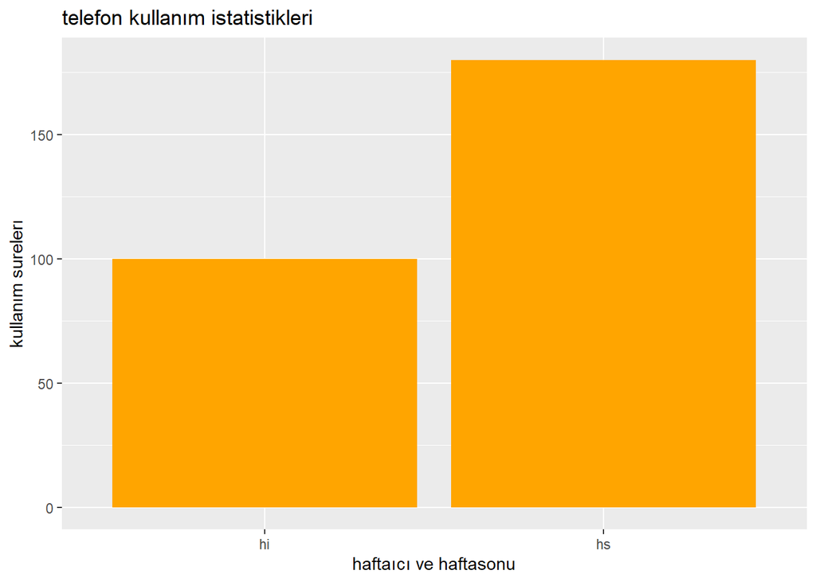

```r
library(ggplot2)
library(tidyr)

df <- tibble(
  kullanım = factor(c("hi" , "hs") , levels= c("hi", "hs")),
  sure= c(100,180)
)
ggplot(data = df ,aes(x=kullanım , y=sure , fill = kullanım))+
  geom_bar(colours ="black", fill = "orange" , stat = "identity") +
  guides(fill = FALSE) +
  xlab("haftaıcı ve haftasonu") + ylab("kullanım surelerı") +
  ggtitle("telefon kullanım istatistikleri")
```

# 1. **TEK DEĞİŞKENLİ GÖRSELLEŞTİRME**

## 1.1 KESİKLİ DEĞİŞKEN

Bu bir kategorik değişken anlamına gelir örneğin cinsiyet, semt,ilçe anne, baba,rütbe vs. bar plot ile görselleşecek ise iki türlü yapılır. birincisi frekans diğeri mutlak değerine göre.

```r
df <- tibble(
  kullanım = c(rep("hi" , 20), rep("hs" , 10))
  )

#Burada evet bir kategirok değişken var ama karşıda değeri ok gözlemleyeceğim şey sadece frekansı
```

## 1.2 SÜREKLİ DEĞİŞKEN

```r
df <- tibble(
  kullanım = factor(c("hi", "hs"), levels= c("hi", "hs")),
  sure = c(100,180)
)
df
```

```
## # A tibble: 2 × 2
##   kullanım  sure
##   <fct>    <dbl>
## 1 hi         100
## 2 hs         180
```

## **KESİKLİ DEĞİŞKEN**

### SÜTUN GRAFİĞİ *(geom_bar)*

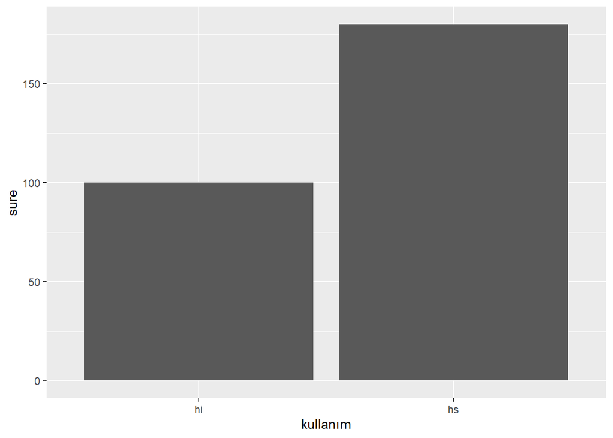

```r
 df <- tibble(
    kullanım = factor(c("hi" , "hs") , levels= c("hi", "hs")),
    sure= c(100,180)
 )
ggplot(df, aes( x = kullanım , y = sure)) +
  geom_bar( stat = "identity")
```

### ÇİZGİ GRAFİĞİ *(geom_line)*

Kategorik değişkenlerin grafiğidir.

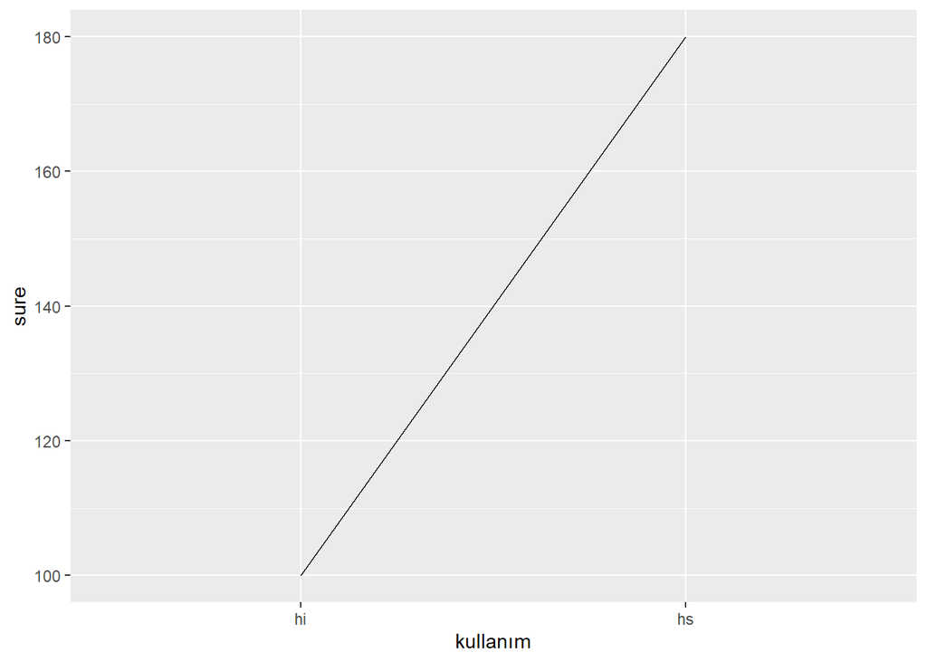

```r
df <- tibble(
    kullanım = factor(c("hi" , "hs") , levels= c("hi", "hs")),
    sure= c(100,180)
 )
ggplot(df, aes( x = kullanım,y= sure , group = 1)) +
  geom_line()
```

örneğin aile fertlerinin boylarının çizgi grafiği

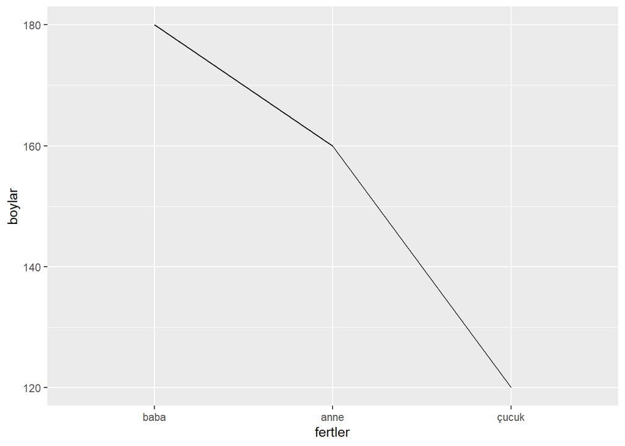

```r
df <- tibble(
    fertler = factor(c("baba" , "anne" , "çucuk"), levels = c("baba" , "anne" , "çucuk")),
    boylar= c(180,160,120)
 )
ggplot(df, aes( x = fertler, y= boylar , group = 1)) +
  geom_line()
```

### NOKTA GRAFİĞİ *(GEOM_POİNT)*

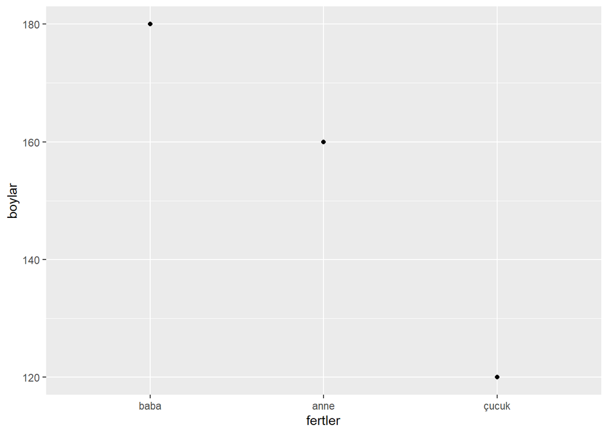

```r
df <- tibble(
    fertler = factor(c("baba" , "anne" , "çucuk"), levels = c("baba" , "anne" , "çucuk")),
    boylar= c(180,160,120)
 )
ggplot(df, aes( x = fertler, y= boylar , group = 1)) +
  geom_point()
```

### ÇİZGİ GRAFİĞİ İLE NOKTA GRAFİĞİNİN BİRLEŞİMİ

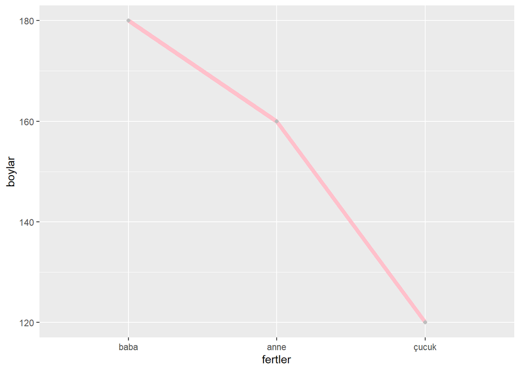

```r
df <- tibble(
    fertler = factor(c("baba" , "anne" , "çucuk"), levels = c("baba" , "anne" , "çucuk")),
    boylar= c(180,160,120)
 )
ggplot(df, aes( x = fertler, y= boylar , group = 1)) +
  geom_line(colour= "pink" , size = 2.0) +
  geom_point( colour =  "gray" , )
```

ÖZELLEŞTİREBİLİRİZ ÖRNEĞİN;

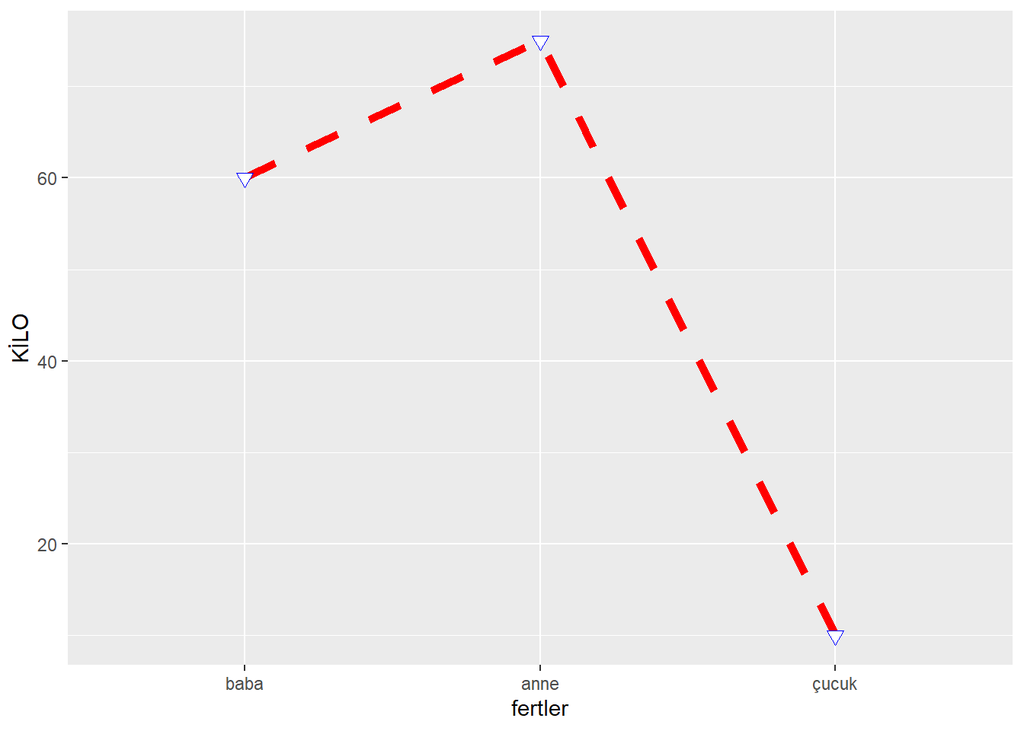

```r
df <- tibble(
    fertler = factor(c("baba" , "anne" , "çucuk"), levels = c("baba" , "anne" , "çucuk")),
    KİLO = c(60,75,10)
 )
ggplot(df, aes( x = fertler, y= KİLO , group = 1)) +
  geom_line( colour = "red" , linetype = "dashed" , size= 2.0) +
  geom_point(colour = "blue" , size = 2.5 , shape = 25 , fill = "white")
```

KİLO, yani y eksenini 0’dan başlatarak grafiği daha anlamlı yapabiliriz. (expand_limits)

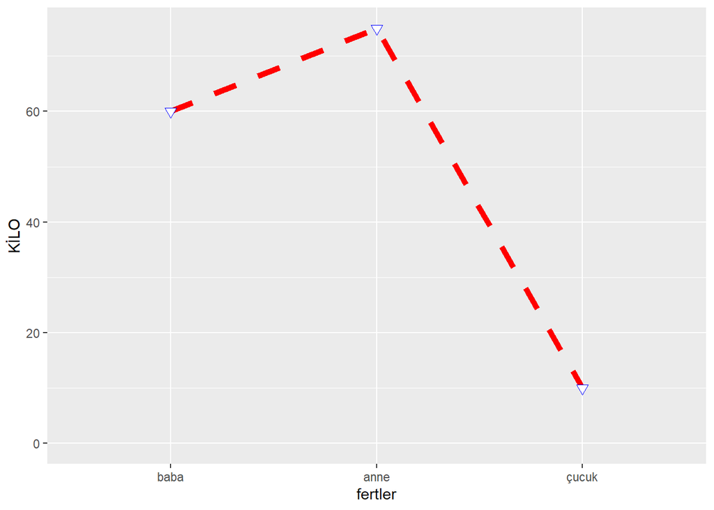

```r
df <- tibble(
    fertler = factor(c("baba" , "anne" , "çucuk"), levels = c("baba" , "anne" , "çucuk")),
    KİLO = c(60,75,10)
 )
ggplot(df, aes( x = fertler, y= KİLO , group = 1)) +
  geom_line( colour = "red" , linetype = "dashed" , size= 2.0) +
  geom_point(colour = "blue" , size = 2.5 , shape = 25 , fill = "white") +
  expand_limits( y = 0)
```

### PASTA GRAFİĞİ

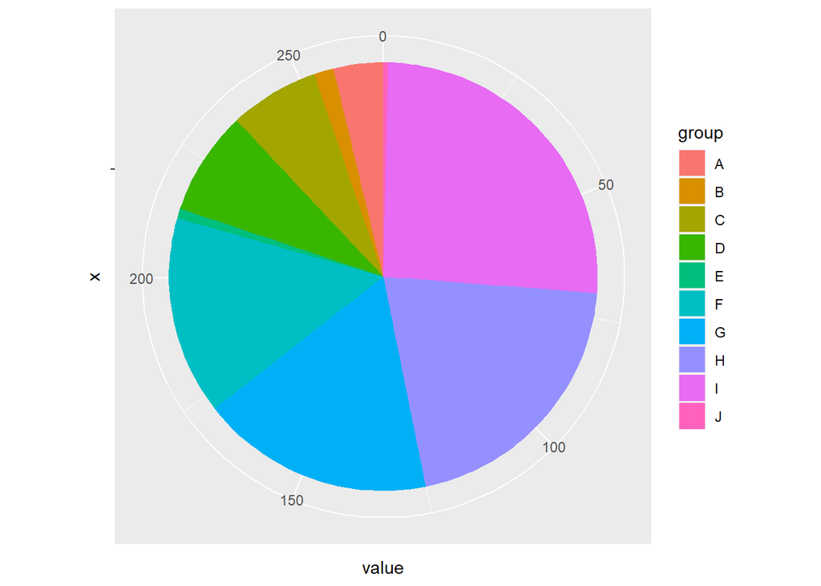

```r
data <- data.frame(
  group=LETTERS[1:10],
  value=c(10,4,18,21,2,40,47,55,69,1)
)

ggplot(data, aes(x="", y=value, fill=group)) +
  geom_bar(stat="identity", width=1) +
  coord_polar("y", start=0)
```

## 1.2 **SÜREKLİ DEĞİŞKEN**

```r
df <- tibble(
  cinsiyet = factor(rep(c("e" , "k") , each = 100)),
  sure = c(rnorm(100, mean=80) , rnorm(100, mean = 81))
)
df
```

```
## # A tibble: 200 × 2
##    cinsiyet  sure
##    <fct>    <dbl>
##  1 e         78.7
##  2 e         79.2
##  3 e         79.0
##  4 e         81.4
##  5 e         79.7
##  6 e         78.5
##  7 e         79.5
##  8 e         78.3
##  9 e         79.0
## 10 e         78.4
## # … with 190 more rows
```

ben bu veriyi nasıl görselleştirebilirim?

### HİSTOGRAM *(GEOM_HİSTOGRAM)*

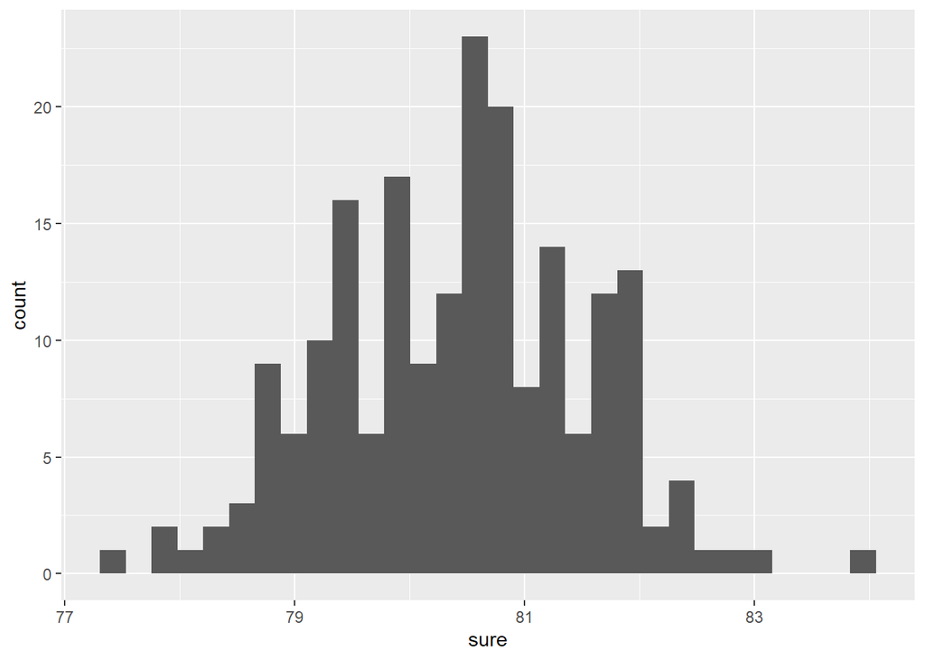

```r
ggplot(df, aes(sure)) +
  geom_histogram()
```

daha okunabilir olması için;

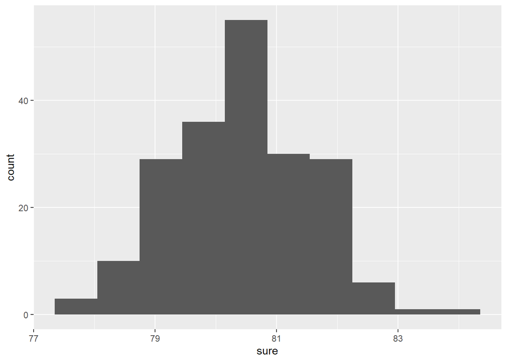

```r
ggplot(df, aes(sure)) +
  geom_histogram(binwidth = 0.7)
```

özelleştirelim;

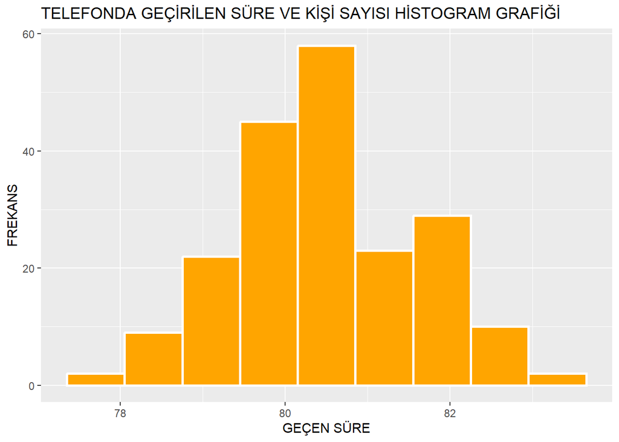

```r
df <- tibble(
  cinsiyet = factor(rep(c("e" , "k") , each = 100)),
  sure = c(rnorm(100, mean=80) , rnorm(100, mean = 81))
)
ggplot(df, aes(sure)) +
  geom_histogram(binwidth = 0.7, colour = "white" , fill= "orange" , size=1) +
  xlab("GEÇEN SÜRE") + ylab("FREKANS") +
  ggtitle("TELEFONDA GEÇİRİLEN SÜRE VE KİŞİ SAYISI HİSTOGRAM GRAFİĞİ")
```

YORUM = **Telefonda 78 dakika süre geçiren kişi sayısı 10 ile 0 arasındadır.**

### YOĞUNLUK FONKSİYONU *(geom_density)*

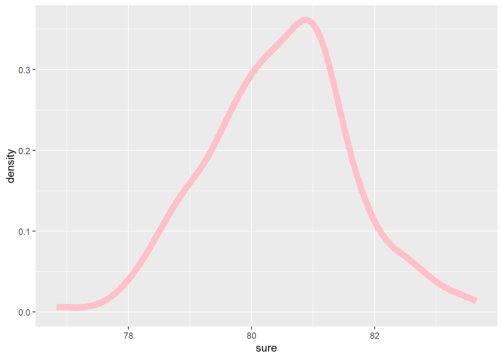

```r
df <- tibble(
  cinsiyet = factor(rep(c("e" , "k") , each = 100)),
  sure = c(rnorm(100, mean=80) , rnorm(100, mean = 81))
)
ggplot(df, aes(sure)) +
  geom_density(colour = "pink" , size= 3)
```

*HİSTOGRAMIN ÜSTÜNE ÇİZDİRMEK İSTİYORUM AMA Y EKSENİ UYUŞMAZLIĞI YAŞANIYOR BKNZ*

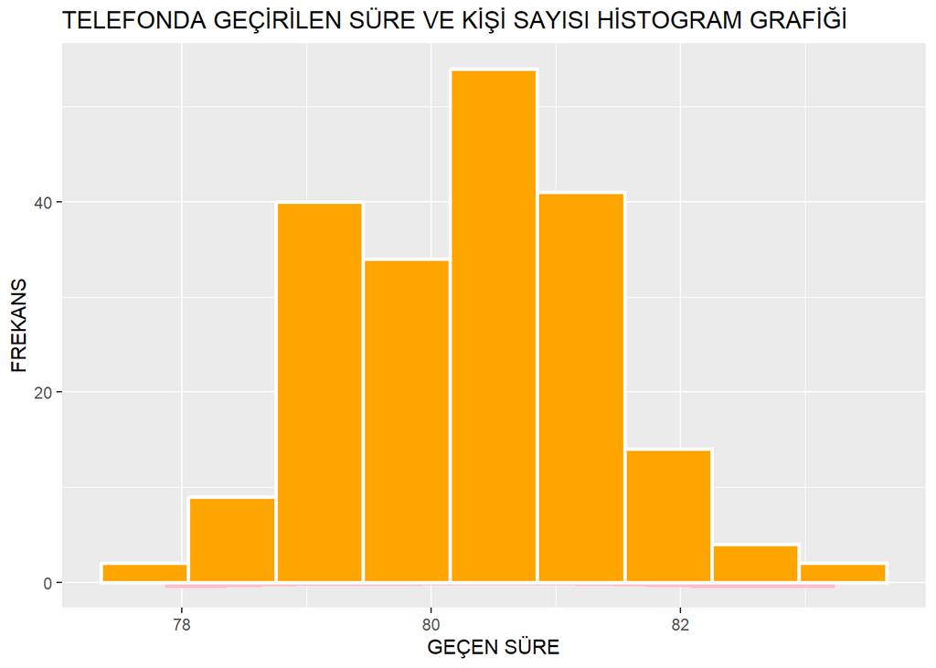

```r
df <- tibble(
  cinsiyet = factor(rep(c("e" , "k") , each = 100)),
  sure = c(rnorm(100, mean=80) , rnorm(100, mean = 81))
)
ggplot(df, aes(sure)) +
 geom_density(colour = "pink" , size= 3) +
  geom_histogram(binwidth = 0.7, colour = "white" , fill= "orange" , size=1) +
  xlab("GEÇEN SÜRE") + ylab("FREKANS") +
  ggtitle("TELEFONDA GEÇİRİLEN SÜRE VE KİŞİ SAYISI HİSTOGRAM GRAFİĞİ")
```

**PEKİ NASIL DÜZELTİRİZ?**

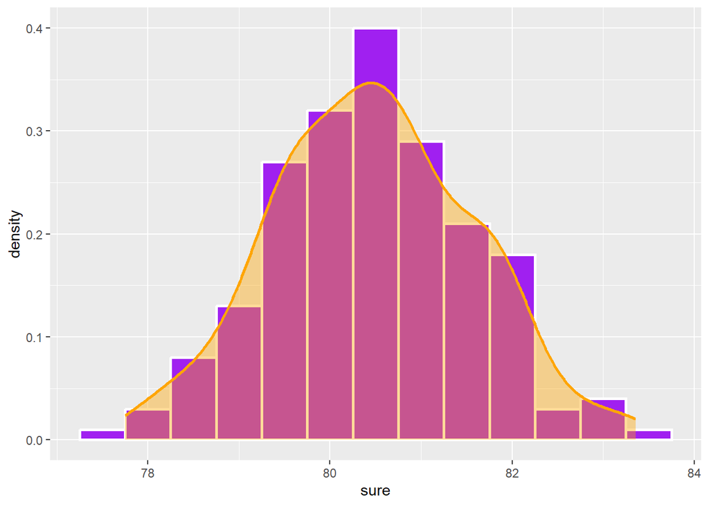

```r
df <- tibble(
  cinsiyet = factor(rep(c("e" , "k") , each = 100)),
  sure = c(rnorm(100, mean=80) , rnorm(100, mean = 81))
)
ggplot(df, aes(sure)) +
  geom_histogram(aes(y=..density..) , binwidth = 0.5, colour = "white" , fill= "purple" , size=1) +
  geom_density( alpha= 0.4, fill= "orange" , colour = "orange" , size= 1)
```

not= alpha transparan özellik

*KIRILMALARA GÖRE HİSTOGRAM VE YOGUNLUK GRAFİGİ*

Elimizde bir veri seti var. Bu verimizde bir adet sürekli bir adet kategorik veri seti var. normallik sağa veya sola çarpıklık direkt histogramı yazdırarak yorumlamak doğru değil. bu yorumu yapabilmek içib kırılıp tekrar göstermemiz gerekir.

**histogram**

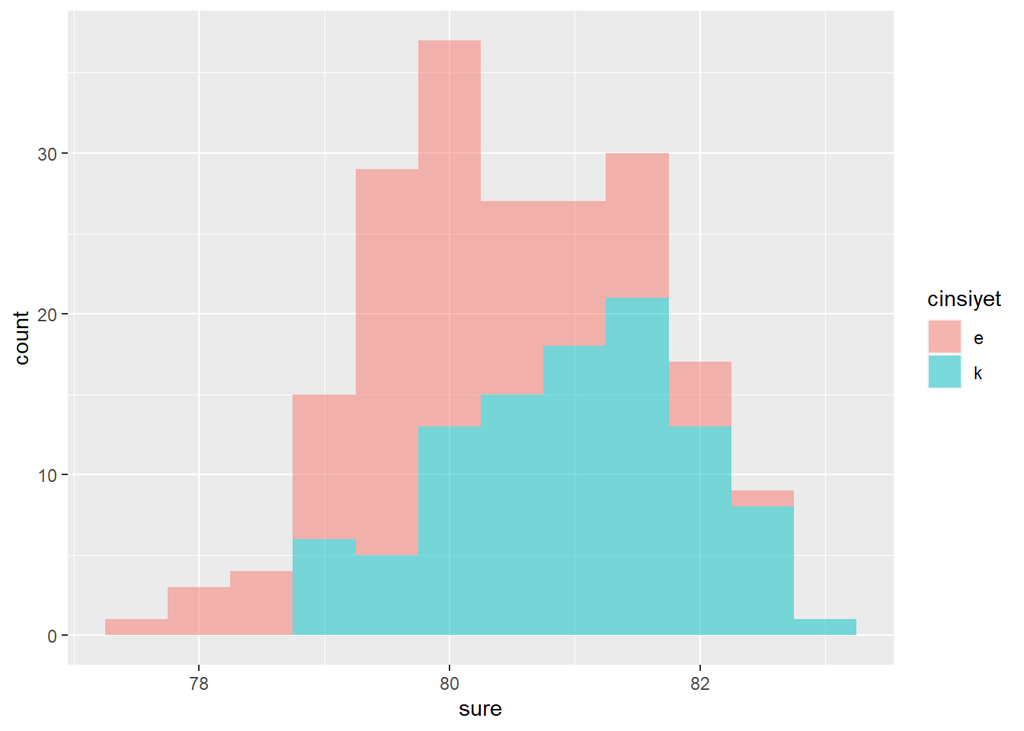

```r
df <- tibble(
  cinsiyet = factor(rep(c("e" , "k") , each = 100)),
  sure = c(rnorm(100, mean=80) , rnorm(100, mean = 81))
)
ggplot(df, aes(sure , fill = cinsiyet)) +
  geom_histogram(binwidth = 0.5, alpha= 0.5, possiton="identity")
```

**yoğunluk**

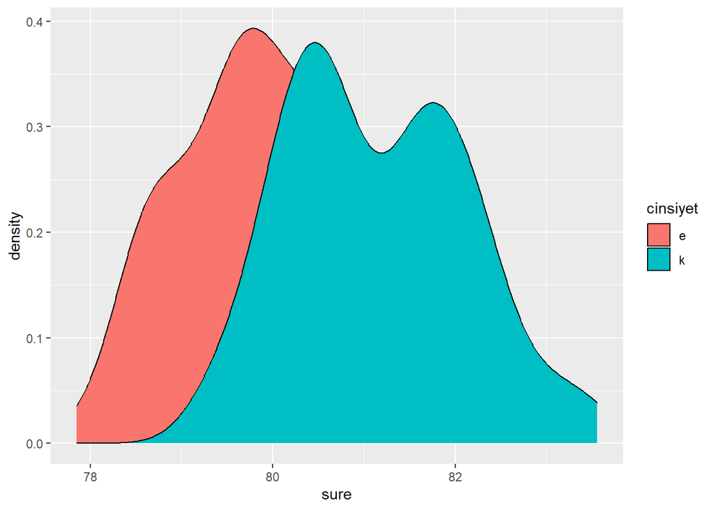

```r
df <- tibble(
  cinsiyet = factor(rep(c("e" , "k") , each = 100)),
  sure = c(rnorm(100, mean=80) , rnorm(100, mean = 81))
)
ggplot(df, aes(sure , fill = cinsiyet)) +
  geom_density()
```

*KIRILMALARI İKİ AYRI GRAFİKLE GÖSTERMEK İÇİN (facet_grid())*

grafikleri bir arada (yukarıdaki örnek) ya da farklı iki ayrı grafik olarak gösterebiliriz.

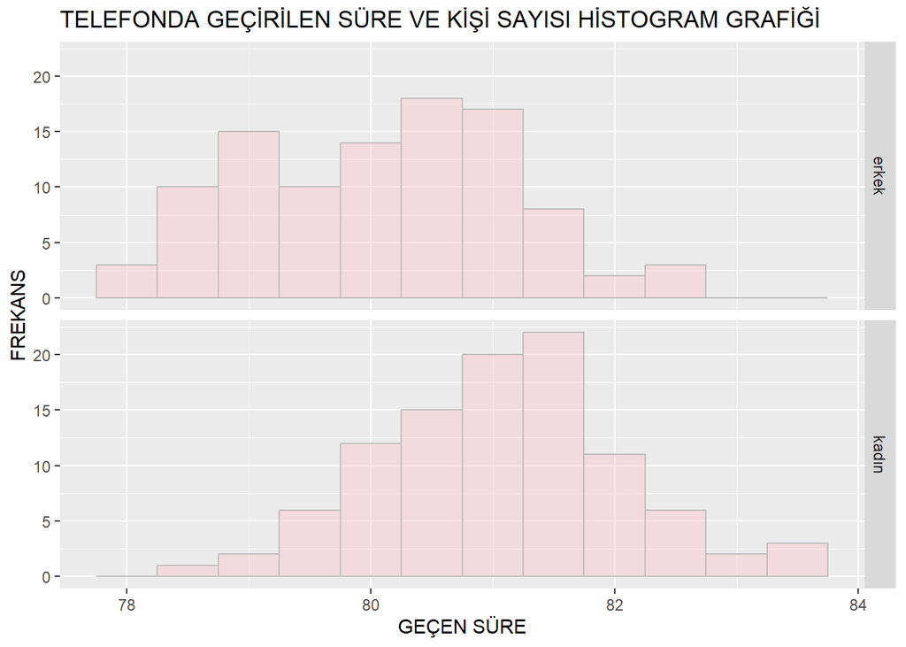

```r
df <- tibble(
  cinsiyet = factor(rep(c("erkek" , "kadın") , each = 100)),
  sure = c(rnorm(100, mean=80) , rnorm(100, mean = 81))
)
ggplot(df, aes(sure , fill = cinsiyet)) +
  geom_histogram(binwidth = 0.5 , colour = "gray" , fill = "pink" , alpha= 0.4)+
  facet_grid(cinsiyet ~ .) +
  xlab("GEÇEN SÜRE") + ylab("FREKANS") +
  ggtitle("TELEFONDA GEÇİRİLEN SÜRE VE KİŞİ SAYISI HİSTOGRAM GRAFİĞİ")
```

### BOX / KUTU GRAFİĞİ *(geom_boxplot)*

Verinin kümelenmesini, yığılmasınının dağılımlarını gösterir.

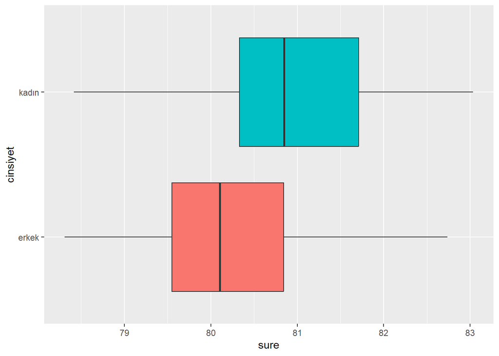

```r
df <- tibble(
  cinsiyet = factor(rep(c("erkek" , "kadın") , each = 100)),
  sure = c(rnorm(100, mean=80) , rnorm(100, mean = 81))
)
ggplot(df, aes( x = cinsiyet , y= sure , fill =cinsiyet)) +
  geom_boxplot()+
  guides(fill= FALSE)+
  coord_flip()
```

### ALAN GRAFİĞİ *(geom_area)*

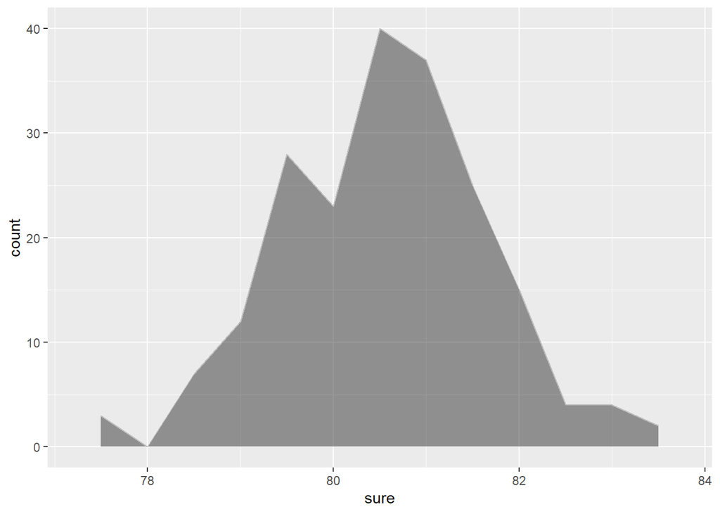

```r
df <- tibble(
  cinsiyet = factor(rep(c("erkek" , "kadın") , each = 100)),
  sure = c(rnorm(100, mean=80) , rnorm(100, mean = 81))
)
ggplot(df, aes(sure)) +
  geom_area(stat="bin" , binwidth= 0.5, colour = "gray" , alpha= .5)
```

### FREKANS GRAFİĞİ *(geom_freqpoly)*

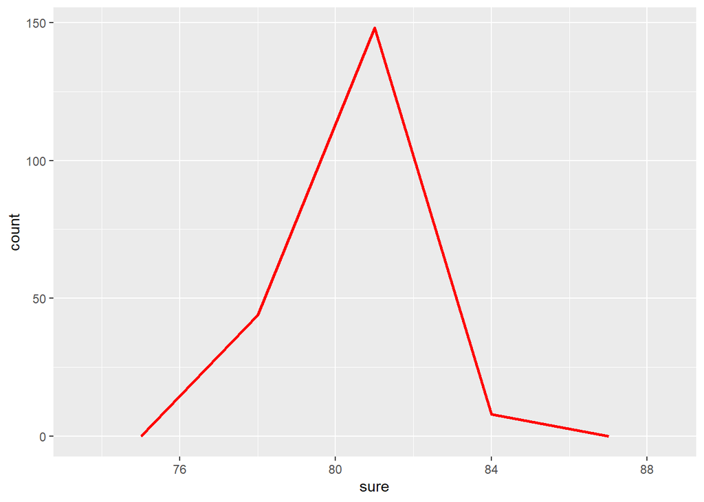

```r
df <- tibble(
  cinsiyet = factor(rep(c("erkek" , "kadın") , each = 100)),
  sure = c(rnorm(100, mean=80) , rnorm(100, mean = 81))
)
ggplot(df, aes(sure)) +
  geom_freqpoly(colour = "red" , size = 1 , bins = 3)
```

### DOT PLOT *(geom_dotplot)*

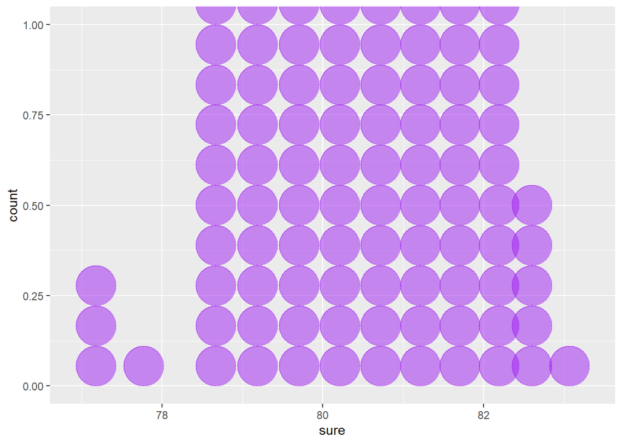

```r
df <- tibble(
  cinsiyet = factor(rep(c("erkek" , "kadın") , each = 100)),
  sure = c(rnorm(100, mean=80) , rnorm(100, mean = 81))
)
ggplot(df, aes(sure)) +
  geom_dotplot(binwidth = 0.5 , colour= "purple" , fill ="purple" , alpha= 0.5)
```

# 2. **İKİ DEĞİŞKENLİ GÖRSELLEŞTİRME**

## 2.1 SÜREKLİ X , SÜREKLİ Y

### SCATTER-PLOT(en çok kullanılan)

verilen iki tane sürekli değişkenin birbirleri ile ilişkisini inceler.

```r
df <- tibble(
  cinsiyet = factor(rep(c("E", "K") , each=500)),
  mobil = c(rnorm(500, mean= 80), rnorm(500, mean=82)),
  web = c(rnorm(500, mean= 82) , rnorm(500, mean= 81))
)
df
```

```
## # A tibble: 1,000 × 3
##    cinsiyet mobil   web
##    <fct>    <dbl> <dbl>
##  1 E         81.5  82.0
##  2 E         80.8  81.7
##  3 E         79.9  83.6
##  4 E         80.8  81.5
##  5 E         80.9  82.2
##  6 E         80.1  82.9
##  7 E         79.0  82.4
##  8 E         81.2  82.4
##  9 E         79.7  83.0
## 10 E         79.0  82.0
## # … with 990 more rows
```

**soru = mobil ile web de geçirilen süre arasında bir korelasyon ilişkisi var mı?**

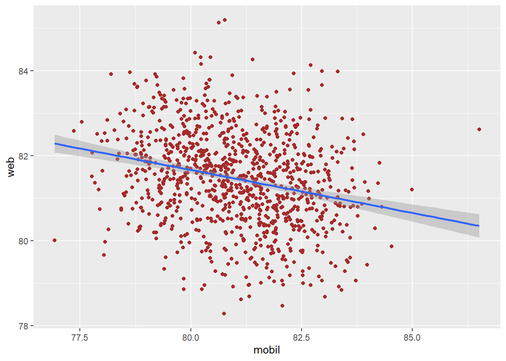

```r
ggplot(df, aes(mobil,web)) +
  geom_point(colour= "brown") +
  geom_smooth(method= lm )
```

yorum= mobil kullanımı arttığında web kullanımı artmıyor.

geom_smooth(method= lm) lm = lineer method

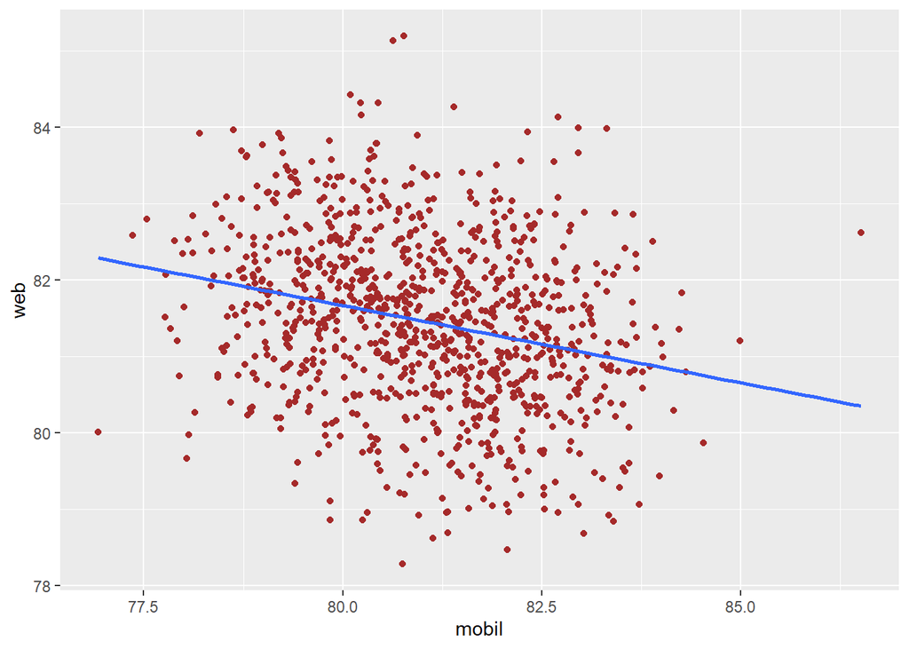

```r
ggplot(df, aes(mobil,web)) +
  geom_point(colour= "brown") +
  geom_smooth(method= lm , se = FALSE)
```

se = FALSE = standard error demek. Çizginin etrafındaki yoğunluk gider.

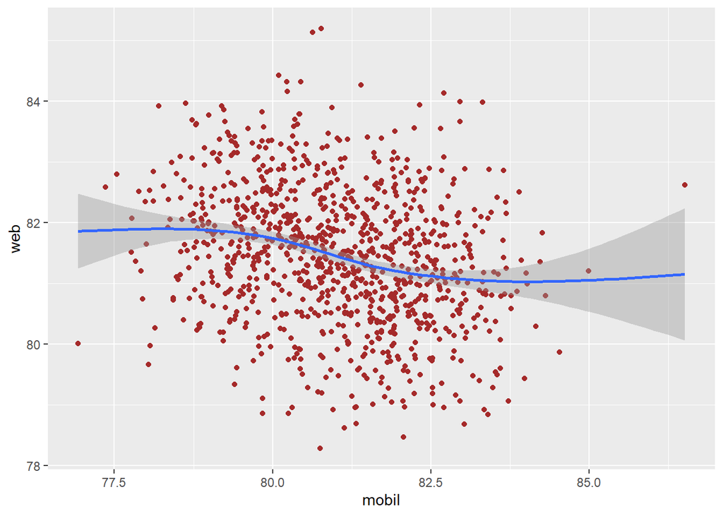

```r
ggplot(df, aes(mobil,web)) +
  geom_point(colour= "brown") +
  geom_smooth()
```

veriyi temsil kabileyeti daha kuvvetli bir veridir.

CİNSİYETE GÖRE BAKALIM;

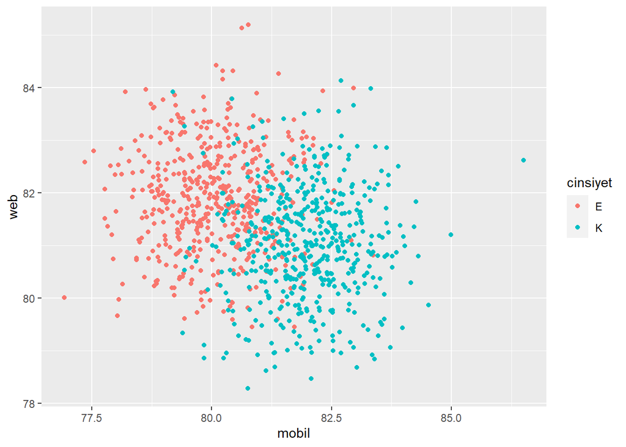

```r
ggplot(df, aes(mobil,web, color= cinsiyet)) +
  geom_point()
```

Renkleri ayırdı. hangisinin kadın olduğunu hangisinin erkek olduğunu görebiliyoruz.

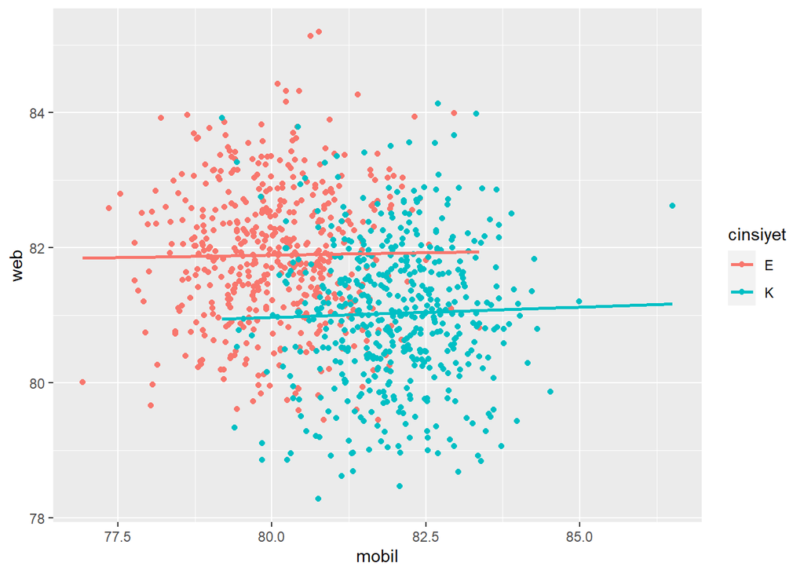

```r
ggplot(df, aes(mobil,web, color = cinsiyet)) +
  geom_point() +
  geom_smooth(method = lm , se = FALSE, formula = 'y ~ x')
```

eğimleri değişmiş oldu.

## 2.2 Kesikli X, Sürekli Y

### Sütun grafikleri *(geom_bar)*

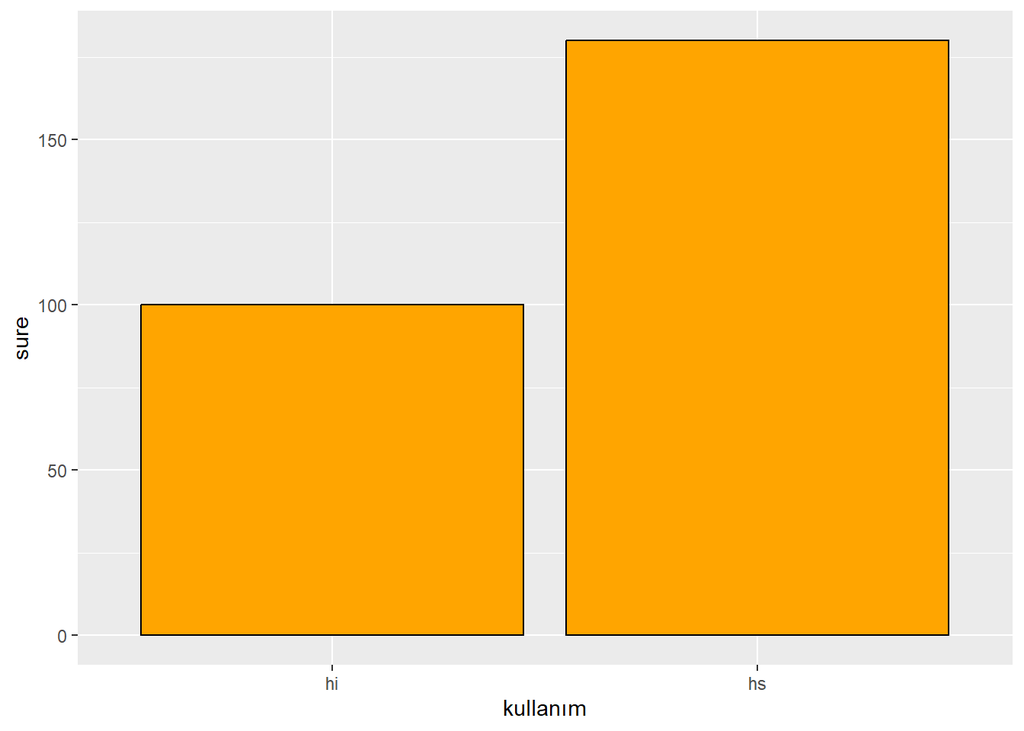

```r
df <- tibble(
  kullanım= factor(c("hi" , "hs"), levels= c("hi", "hs")),
  sure =c(100,180)
)
ggplot(df, aes(kullanım , sure , fill =kullanım)) +
  geom_bar(colour = "black", fill= "orange", stat ="identity")
```

### BOX PLOT *(geom_boxplot)*

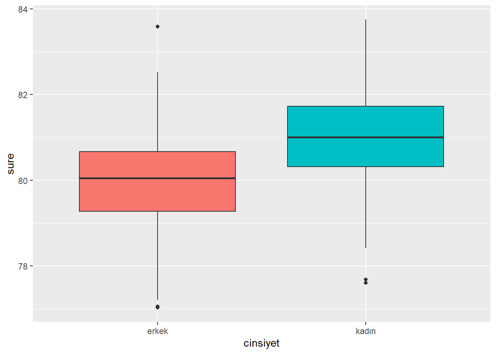

```r
df <- tibble(
  cinsiyet = factor(rep(c("erkek" , "kadın") , each = 500)),
  sure = c(rnorm(500, mean=80) , rnorm(500, mean = 81))
)
ggplot(df, aes( x = cinsiyet , y= sure , fill =cinsiyet)) +
  geom_boxplot()+
  guides(fill= FALSE)
```

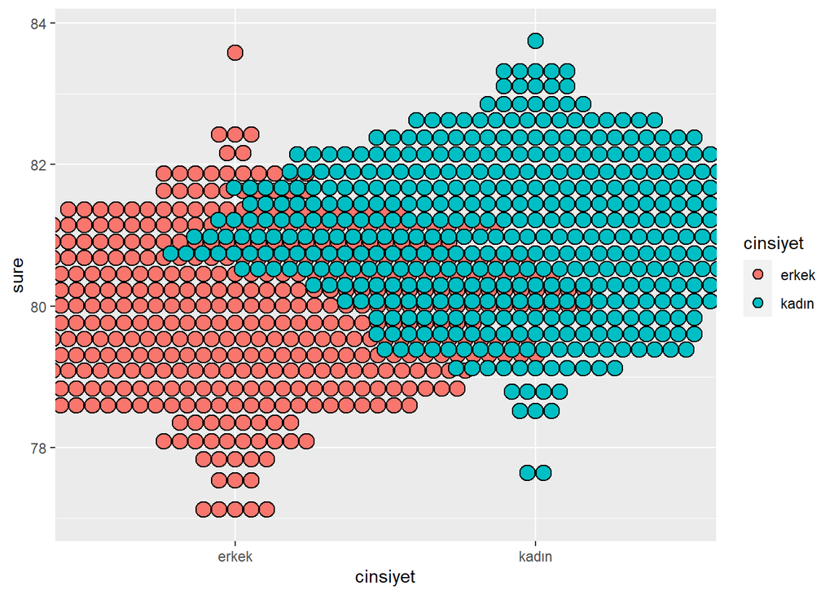

```r
ggplot(df, aes( x = cinsiyet , y= sure , fill =cinsiyet)) +
  geom_dotplot(binaxis = "y" , stackdir = "center")
```

### VİOLİN *(geom_violin*)*

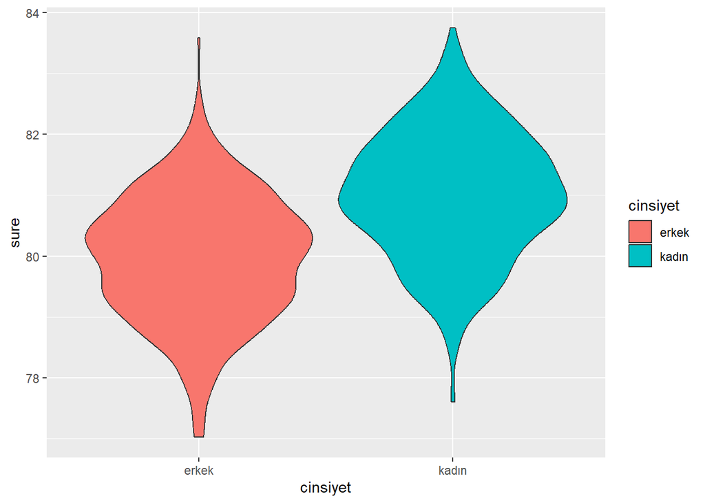

```r
ggplot(df, aes( x = cinsiyet , y= sure , fill =cinsiyet)) +
  geom_violin(scale= "area")
```

## 2.3 KESİKLİ X, KESİKLİ Y

(ikisi de kategorik)

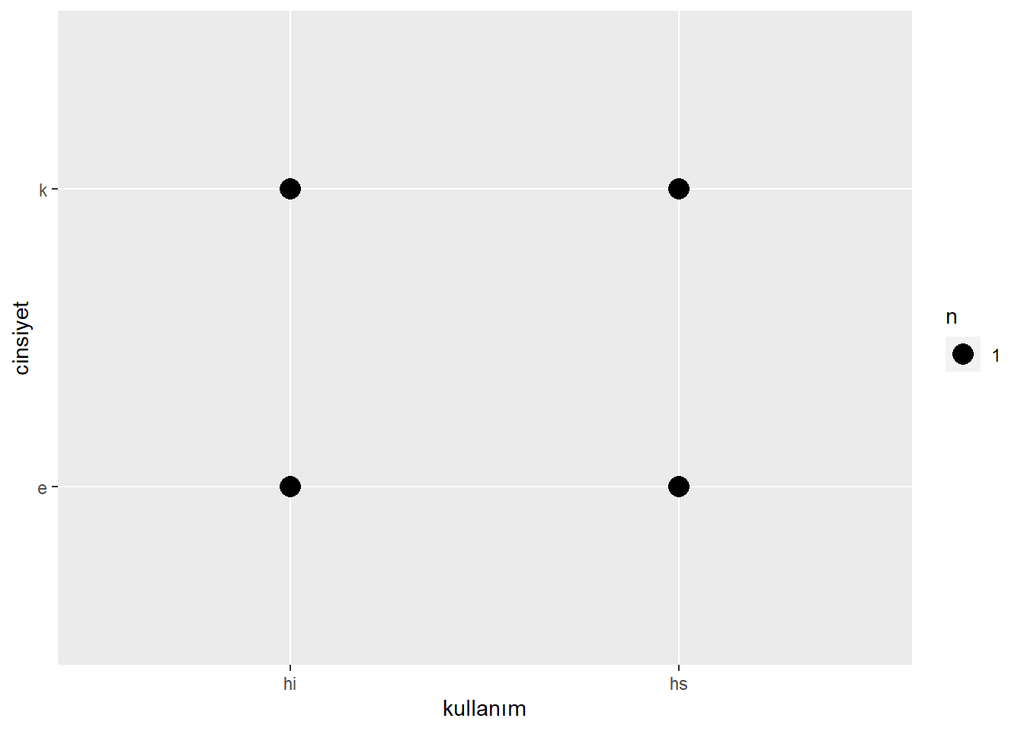

```r
df<- tibble(
  kullanım = factor(c("hi","hs","hi", "hs"), levels=c("hi","hs")),
  sure=c(100,180,90,200),
  cinsiyet= factor(c("e","e","k","k"))
)
ggplot(df, aes(kullanım, cinsiyet)) +
  geom_count()
```